# Instructor Group Predictions

# Cadet Group Predictions

#### CBS Sports

This week we beat or tied 4 of 8 CBS Sports’ Experts.

For the season we are currently beating or tied with 4 of 8 CBS Sports’ Experts.

#### ESPN

We also beat or tied 3 of 11 ESPN Experts.

For the season we are currently beating or tied with 6 of 11 ESPN Experts.

### Win percentage for the week

[interactive chart not shown]

### Season Win Percent

[interactive chart not shown]

### Games Correct

177

### Games Picked

283

### Predictions

12

This Week's MA376 Predictions

Week 22

| Game | Prediction | Winner | Correct | Correct Votes | Correct Percent |
| --- | --- | --- | --- | --- | --- |
| 1 | Cincinnati Bengals | Los Angeles Rams | No | 3 | 0.25 |

[interactive chart not shown]

# Cadet Individual Predictions

#### Best Picks of the Week.

Sammy Whipple, Ryan Santoro, Tyler Vratny

#### Best Season Correct Percentage

Ryan Smith

#### Best Adjusted Season Correct Percentage

Ryan Santoro

- Adjusted season percentage accounts for the number of weeks picked.

### Cadet Individual Table

MA376 Individual Results

Week 22

Name

Weekly # Correct

Percent

Weeks Picked

Season Percent

Adj Season Percent

Season Trend

Week 1

Week 2

Week 3

Week 4

Week 5

Week 6

Week 7

Week 8

Week 9

Week 10

Week 11

Week 12

Week 13

Week 14

Week 15

Week 16

Week 17

Week 18

Week 19

Week 20

Week 21

Week 22

Sammy Whipple

8

11

10

NA

10

11

10

9

7

5

11

NA

9

9

13

13

13

8

5

2

1

1

1

20

0.6640

0.6036

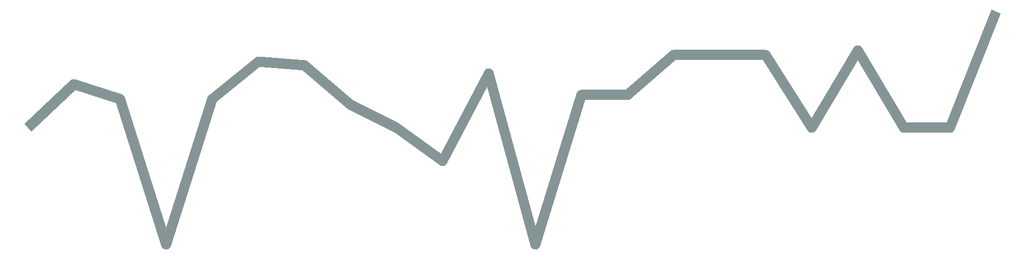

Ryan Santoro

12

11

12

11

NA

9

9

10

6

7

10

8

10

8

8

13

13

8

4

1

0

1

1

21

0.6453

0.6160

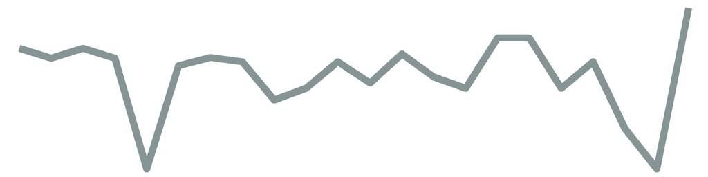

Tyler Vratny

9

8

9

NA

11

5

NA

7

NA

NA

NA

NA

NA

NA

NA

NA

NA

NA

NA

4

2

1

1

9

0.5714

0.2338

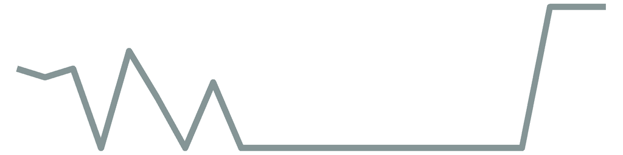

Cameron Jones

NA

12

13

9

12

8

9

9

6

6

8

11

9

10

NA

11

14

9

4

2

1

0

0

20

0.6546

0.5951

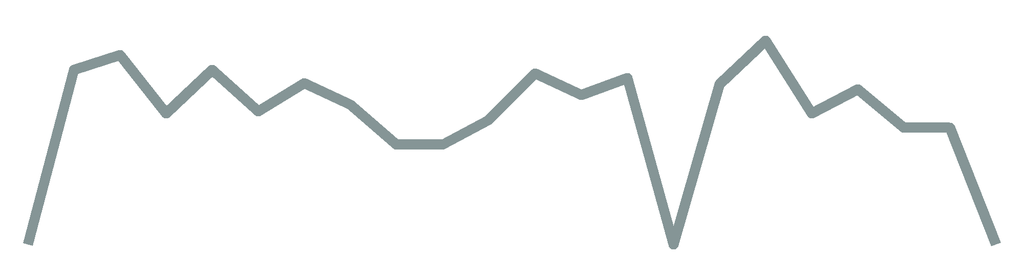

Elijah Dabkowski

NA

10

10

8

11

8

11

9

9

8

10

9

9

9

10

9

11

10

3

3

1

0

0

21

0.6340

0.6052

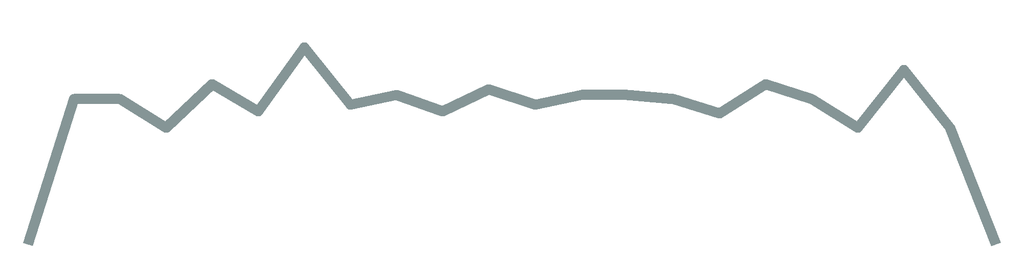

Tyler Guetzke

NA

9

9

10

13

9

10

7

6

5

9

10

9

9

12

NA

NA

NA

5

1

1

0

0

18

0.6175

0.5052

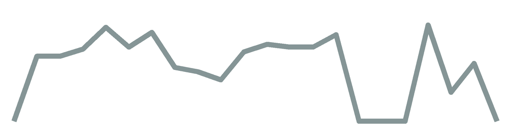

Christopher Terry

8

9

11

NA

10

10

10

NA

NA

4

NA

NA

NA

9

9

NA

NA

NA

NA

NA

NA

0

0

10

0.6015

0.2734

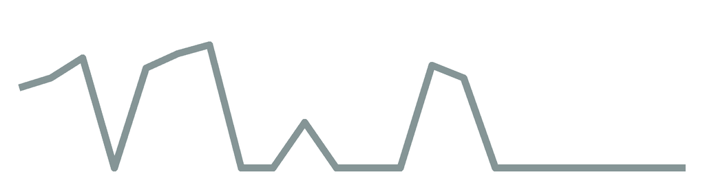

Jack Perreault

9

8

10

11

11

9

8

9

6

7

10

NA

8

NA

9

10

NA

NA

NA

2

NA

0

0

16

0.5991

0.4357

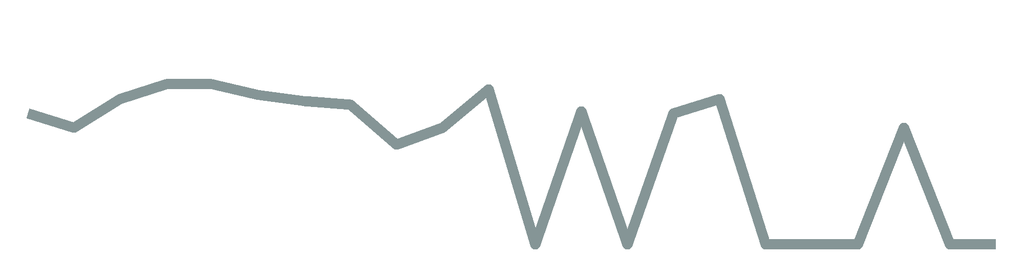

Bethany Carter

9

9

7

7

11

9

7

10

7

7

7

10

8

10

7

9

12

10

5

0

1

0

0

22

0.5765

0.5765

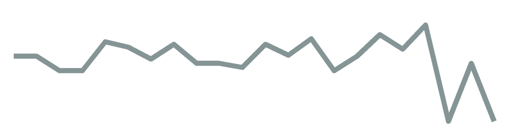

Caroline Swenson

9

9

9

8

10

9

9

7

6

NA

9

9

9

8

9

9

NA

8

NA

1

1

0

0

19

0.5673

0.4899

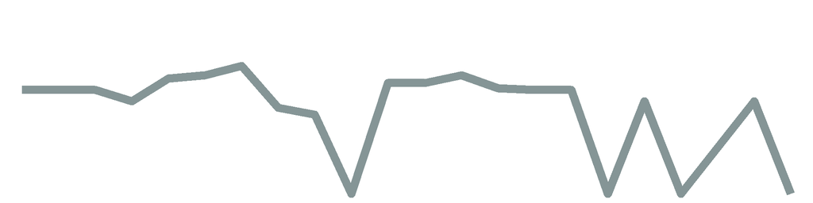

Anders Grau

6

9

10

8

11

7

NA

8

7

5

8

10

8

9

9

NA

NA

NA

NA

1

2

0

0

17

0.5463

0.4221

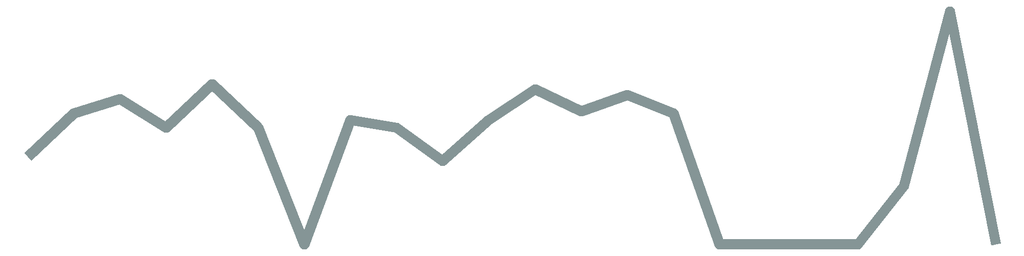

Samuel Deruse

NA

8

8

NA

11

6

9

NA

NA

NA

8

NA

7

6

NA

NA

NA

8

3

NA

NA

0

0

11

0.5362

0.2681

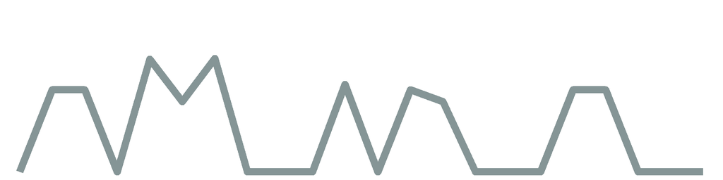

Ryan Smith

NA

12

NA

NA

NA

NA

NA

NA

NA

NA

NA

NA

NA

NA

NA

NA

NA

NA

NA

NA

NA

NA

0

1

0.8000

0.0364

[figure not shown]

Stanley Liu

NA

13

11

10

10

10

NA

NA

NA

7

NA

NA

NA

NA

12

NA

NA

NA

NA

3

1

NA

0

9

0.6814

0.2788

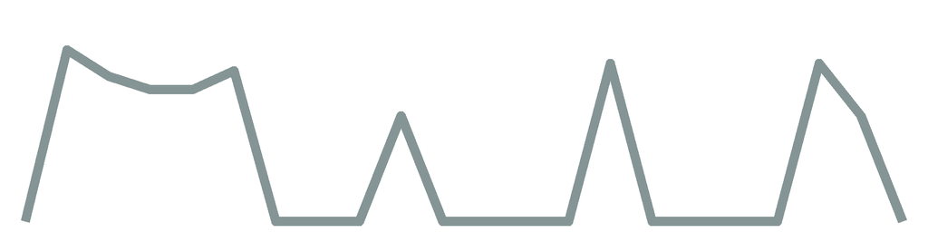

Maurice Bellan

NA

9

NA

12

NA

NA

NA

NA

NA

NA

NA

NA

NA

NA

NA

NA

NA

NA

NA

NA

NA

NA

0

2

0.6774

0.0616

[figure not shown]

John White

NA

NA

NA

NA

NA

NA

NA

NA

NA

NA

NA

NA

NA

9

NA

NA

NA

NA

NA

NA

NA

NA

0

1

0.6429

0.0292

[figure not shown]

Isaiah Smith

12

NA

10

5

NA

10

9

NA

NA

NA

NA

NA

NA

NA

NA

NA

NA

NA

NA

NA

NA

NA

0

5

0.6301

0.1432

[figure not shown]

Mitchell Miller

10

8

10

9

11

9

10

8

7

6

8

10

9

10

7

11

NA

NA

5

NA

NA

NA

0

17

0.6116

0.4726

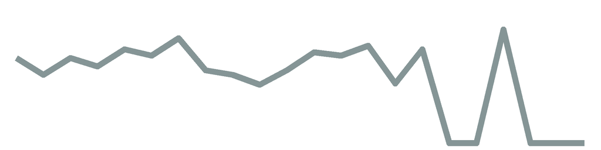

Chloe Zendt

6

8

11

12

12

9

7

9

7

6

10

7

9

8

12

NA

NA

NA

NA

NA

NA

NA

0

15

0.6045

0.4122

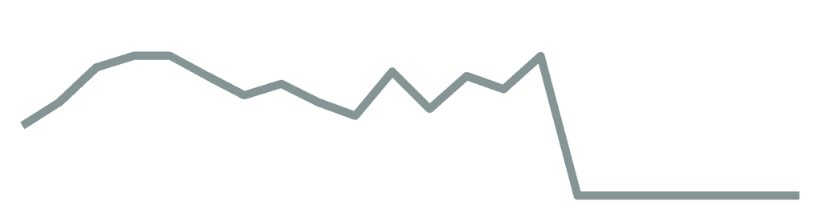

Kiersten Eggers

10

9

8

9

13

8

10

8

7

6

7

9

10

NA

NA

NA

NA

NA

NA

NA

NA

NA

0

13

0.6000

0.3545

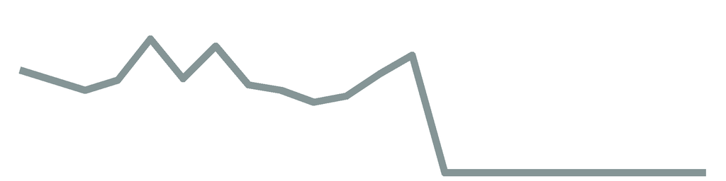

Bennett Smith

8

10

9

10

9

8

10

NA

8

6

8

NA

NA

NA

NA

NA

NA

NA

5

NA

NA

NA

0

11

0.5948

0.2974

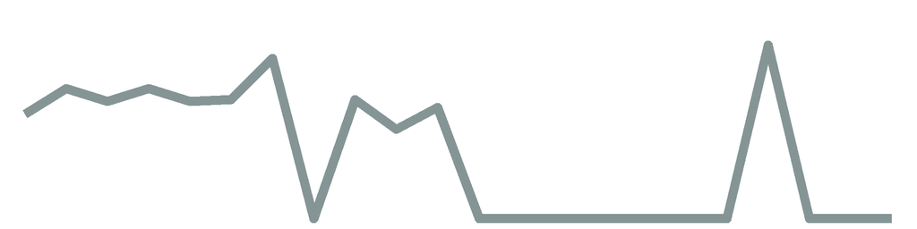

Robert Warren

10

8

10

10

11

9

7

8

5

7

10

8

NA

NA

NA

NA

NA

NA

NA

NA

NA

NA

0

12

0.5852

0.3192

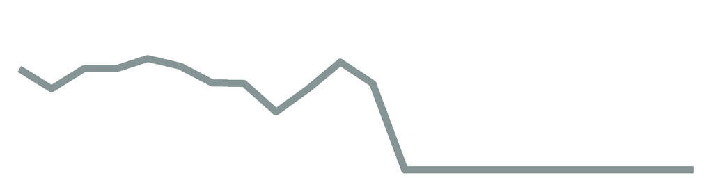

Colin Day

7

10

12

10

9

9

9

NA

8

6

9

4

10

9

8

NA

NA

NA

NA

NA

NA

NA

0

14

0.5825

0.3707

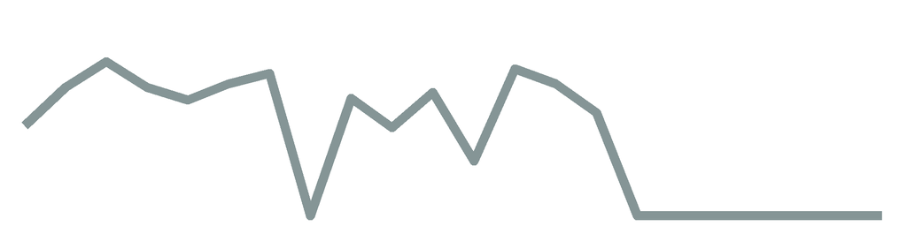

Gregg Puttkammer

6

10

10

11

12

8

7

10

6

6

9

6

NA

9

NA

NA

NA

NA

NA

NA

NA

NA

0

13

0.5789

0.3421

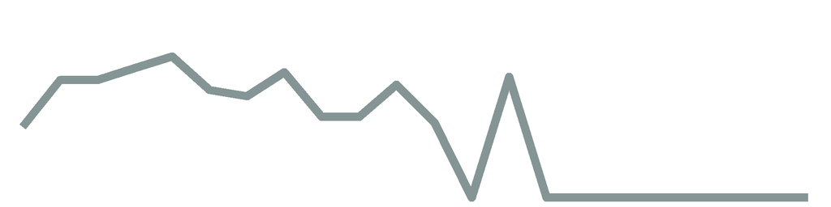

Henry Janeway

7

9

NA

10

NA

6

9

NA

NA

NA

NA

NA

NA

NA

NA

NA

NA

NA

NA

NA

NA

NA

0

5

0.5694

0.1294

[figure not shown]

Seth Benson

5

10

13

9

9

7

8

NA

NA

6

NA

NA

NA

NA

NA

NA

NA

NA

NA

NA

NA

NA

0

8

0.5678

0.2065

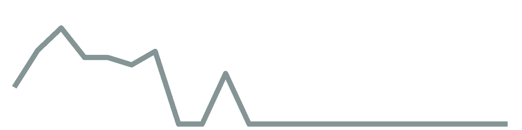

Erika Hartel

9

NA

NA

NA

NA

NA

NA

NA

NA

NA

NA

NA

NA

NA

NA

NA

NA

NA

NA

NA

NA

NA

0

1

0.5625

0.0256

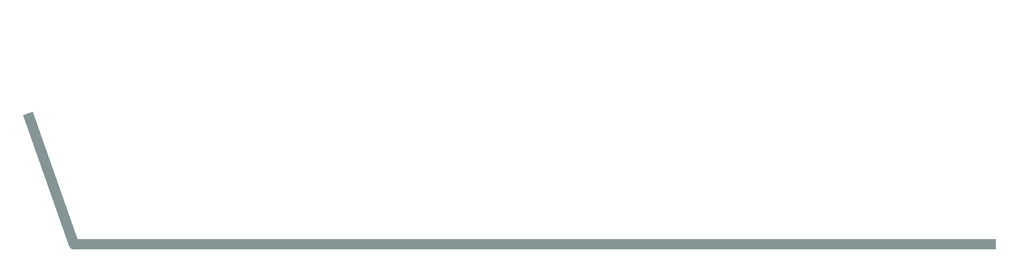

Aaron Bonner

NA

NA

11

7

NA

NA

NA

NA

NA

NA

NA

NA

NA

NA

NA

NA

NA

NA

NA

NA

NA

NA

0

2

0.5625

0.0511

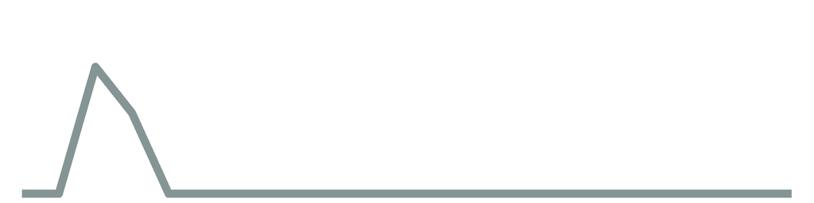

Alechandra Terenas

NA

8

NA

NA

NA

NA

NA

NA

NA

NA

NA

NA

NA

NA

NA

NA

NA

NA

NA

NA

NA

NA

0

1

0.5333

0.0242

[figure not shown]

Oscar Morales

11

NA

4

NA

8

NA

NA

NA

NA

NA

NA

NA

NA

NA

NA

NA

NA

NA

NA

NA

NA

NA

0

3

0.4792

0.0653

[figure not shown]

Nicole Sacchinelli

NA

4

NA

NA

NA

NA

NA

NA

NA

NA

NA

NA

NA

NA

NA

NA

NA

NA

NA

2

NA

NA

0

2

0.3158

0.0287

[figure not shown]

### Cadet Individual Plots

[interactive chart not shown]

# Combined Predictions

#### CBS Sports

This week our combined predictions beat or tied 4 of 8 CBS Sports’ Experts.

For the season we are currently beating or tied with 4 of 8 CBS Sports’ Experts.

#### ESPN

Our combined predictions also beat or tied 3 of 11 ESPN Experts.

For the season our combined predictions are currently beating or tied with 5 of 11 ESPN Experts.

### Win percentage for the week

[interactive chart not shown]

### Season Win Percent

[interactive chart not shown]

### Games Correct

176

### Games Picked

284

### Number of Predictions

31

This Week's Combined Cadet and Instructor Predictions

Week 22

| Game | Prediction | Winner | Correct | Correct Votes | Correct Percent |
| --- | --- | --- | --- | --- | --- |
| 1 | Cincinnati Bengals | Los Angeles Rams | No | 9 | 0.2903 |

[interactive chart not shown]

# Matched Predictions

### Win percentage for the week

[interactive chart not shown]

### Season Win Percent

[interactive chart not shown]

### Games Picked

260

### Season Games Correct

164

This Week's Matched Cadet and Instructor Predictions

Week 22

| Game | Prediction | Correct |
| --- | --- | --- |
| 1 | Cincinnati Bengals | No |

[interactive chart not shown]

# Instructor Data

|  | Week | Name | Game 1 | Game 2 | Game 3 | Game 4 | Game 5 | Game 6 | Game 7 | Game 8 | Game 9 | Game 10 | Game 11 | Game 12 | Game 13 | Game 14 | Game 15 | Game 16 |
| --- | --- | --- | --- | --- | --- | --- | --- | --- | --- | --- | --- | --- | --- | --- | --- | --- | --- | --- |
| 1 | 1 | Gabriel Costa | Tampa Bay Buccaneers | Tennessee Titans | Houston Texans | Washington Football Team | Minnesota Vikings | Carolina Panthers | Philadelphia Eagles | Buffalo Bills | Indianapolis Colts | San Francisco 49ers | Kansas City Chiefs | New York Giants | Green Bay Packers | Miami Dolphins | Los Angeles Rams | Baltimore Ravens |
| 2 | 1 | John Kearby | Tampa Bay Buccaneers | Tennessee Titans | Jacksonville Jaguars | Washington Football Team | Minnesota Vikings | Carolina Panthers | Philadelphia Eagles | Buffalo Bills | Seattle Seahawks | San Francisco 49ers | Kansas City Chiefs | Denver Broncos | Green Bay Packers | New England Patriots | Los Angeles Rams | Baltimore Ravens |
| 3 | 1 | Margaret Wieczorek | Tampa Bay Buccaneers | Tennessee Titans | Jacksonville Jaguars | Los Angeles Chargers | Minnesota Vikings | Carolina Panthers | Atlanta Falcons | Buffalo Bills | Seattle Seahawks | San Francisco 49ers | Kansas City Chiefs | Denver Broncos | New Orleans Saints | New England Patriots | Chicago Bears | Baltimore Ravens |
| 4 | 1 | Blake Schwartz | Tampa Bay Buccaneers | Arizona Cardinals | Houston Texans | Los Angeles Chargers | Minnesota Vikings | Carolina Panthers | Atlanta Falcons | Pittsburgh Steelers | Indianapolis Colts | San Francisco 49ers | Kansas City Chiefs | Denver Broncos | New Orleans Saints | New England Patriots | Chicago Bears | Baltimore Ravens |
| 5 | 1 | Eric Swenson | Tampa Bay Buccaneers | Arizona Cardinals | Jacksonville Jaguars | Washington Football Team | Minnesota Vikings | Carolina Panthers | Philadelphia Eagles | Pittsburgh Steelers | Seattle Seahawks | San Francisco 49ers | Kansas City Chiefs | New York Giants | Green Bay Packers | New England Patriots | Los Angeles Rams | Baltimore Ravens |
| 6 | 1 | Jeremy Reynolds | Tampa Bay Buccaneers | Tennessee Titans | Jacksonville Jaguars | Washington Football Team | Minnesota Vikings | New York Jets | Philadelphia Eagles | Buffalo Bills | Seattle Seahawks | San Francisco 49ers | Kansas City Chiefs | New York Giants | Green Bay Packers | Miami Dolphins | Los Angeles Rams | Las Vegas Raiders |
| 7 | 1 | James Starling | Tampa Bay Buccaneers | Tennessee Titans | Jacksonville Jaguars | Los Angeles Chargers | Minnesota Vikings | Carolina Panthers | Atlanta Falcons | Buffalo Bills | Seattle Seahawks | San Francisco 49ers | Kansas City Chiefs | Denver Broncos | Green Bay Packers | New England Patriots | Chicago Bears | Baltimore Ravens |
| 8 | 1 | Shane Clark | Tampa Bay Buccaneers | Tennessee Titans | Jacksonville Jaguars | Washington Football Team | Minnesota Vikings | New York Jets | Atlanta Falcons | Buffalo Bills | Seattle Seahawks | San Francisco 49ers | Kansas City Chiefs | New York Giants | Green Bay Packers | Miami Dolphins | Chicago Bears | Baltimore Ravens |
| 9 | 1 | Jonathan Roginski | Tampa Bay Buccaneers | Tennessee Titans | Jacksonville Jaguars | Washington Football Team | Cincinnati Bengals | New York Jets | Atlanta Falcons | Pittsburgh Steelers | Indianapolis Colts | San Francisco 49ers | Kansas City Chiefs | Denver Broncos | Green Bay Packers | New England Patriots | Chicago Bears | Baltimore Ravens |
| 10 | 1 | Michael Prokos | Tampa Bay Buccaneers | Tennessee Titans | Jacksonville Jaguars | Los Angeles Chargers | Minnesota Vikings | Carolina Panthers | Philadelphia Eagles | Buffalo Bills | Seattle Seahawks | Detroit Lions | Kansas City Chiefs | Denver Broncos | Green Bay Packers | New England Patriots | Los Angeles Rams | Las Vegas Raiders |

[output cut: 468 more lines]

# Cadet Data

|  | Week | Name | Game 1 | Game 2 | Game 3 | Game 4 | Game 5 | Game 6 | Game 7 | Game 8 | Game 9 | Game 10 | Game 11 | Game 12 | Game 13 | Game 14 | Game 15 | Game 16 |
| --- | --- | --- | --- | --- | --- | --- | --- | --- | --- | --- | --- | --- | --- | --- | --- | --- | --- | --- |
| 1 | 1 | Colin Day | Tampa Bay Buccaneers | Tennessee Titans | Jacksonville Jaguars | Los Angeles Chargers | Minnesota Vikings | New York Jets | Atlanta Falcons | Buffalo Bills | Seattle Seahawks | San Francisco 49ers | Kansas City Chiefs | New York Giants | Green Bay Packers | Miami Dolphins | Los Angeles Rams | Baltimore Ravens |
| 2 | 1 | Mitchell Miller | Dallas Cowboys | Tennessee Titans | Houston Texans | Los Angeles Chargers | Cincinnati Bengals | New York Jets | Atlanta Falcons | Pittsburgh Steelers | Seattle Seahawks | San Francisco 49ers | Cleveland Browns | New York Giants | New Orleans Saints | Miami Dolphins | Los Angeles Rams | Las Vegas Raiders |
| 3 | 1 | Seth Benson | Tampa Bay Buccaneers | Tennessee Titans | Jacksonville Jaguars | Washington Football Team | Minnesota Vikings | Carolina Panthers | Atlanta Falcons | Buffalo Bills | Indianapolis Colts | Detroit Lions | Cleveland Browns | Denver Broncos | Green Bay Packers | Miami Dolphins | Los Angeles Rams | Baltimore Ravens |
| 4 | 1 | Ryan Santoro | Tampa Bay Buccaneers | Arizona Cardinals | Houston Texans | Washington Football Team | Minnesota Vikings | Carolina Panthers | Philadelphia Eagles | Buffalo Bills | Seattle Seahawks | San Francisco 49ers | Kansas City Chiefs | Denver Broncos | New Orleans Saints | New England Patriots | Los Angeles Rams | Las Vegas Raiders |
| 5 | 1 | Erika Hartel | Dallas Cowboys | Arizona Cardinals | Jacksonville Jaguars | Los Angeles Chargers | Minnesota Vikings | New York Jets | Philadelphia Eagles | Pittsburgh Steelers | Seattle Seahawks | San Francisco 49ers | Kansas City Chiefs | Denver Broncos | Green Bay Packers | Miami Dolphins | Chicago Bears | Baltimore Ravens |
| 6 | 1 | Bennett Smith | Tampa Bay Buccaneers | Tennessee Titans | Jacksonville Jaguars | Los Angeles Chargers | Cincinnati Bengals | Carolina Panthers | Philadelphia Eagles | Buffalo Bills | Indianapolis Colts | San Francisco 49ers | Kansas City Chiefs | New York Giants | Green Bay Packers | New England Patriots | Los Angeles Rams | Baltimore Ravens |
| 7 | 1 | Anders Grau | Tampa Bay Buccaneers | Tennessee Titans | Jacksonville Jaguars | Los Angeles Chargers | Minnesota Vikings | New York Jets | Atlanta Falcons | Buffalo Bills | Seattle Seahawks | Detroit Lions | Kansas City Chiefs | New York Giants | New Orleans Saints | New England Patriots | Los Angeles Rams | Baltimore Ravens |
| 8 | 1 | Bethany Carter | Tampa Bay Buccaneers | Arizona Cardinals | Houston Texans | Washington Football Team | Minnesota Vikings | Carolina Panthers | Philadelphia Eagles | Buffalo Bills | Seattle Seahawks | San Francisco 49ers | Kansas City Chiefs | New York Giants | New Orleans Saints | New England Patriots | Chicago Bears | Baltimore Ravens |
| 9 | 1 | Gregg Puttkammer | Tampa Bay Buccaneers | Tennessee Titans | Jacksonville Jaguars | Los Angeles Chargers | Minnesota Vikings | New York Jets | Atlanta Falcons | Buffalo Bills | Seattle Seahawks | San Francisco 49ers | Kansas City Chiefs | Denver Broncos | Green Bay Packers | New England Patriots | Chicago Bears | Baltimore Ravens |
| 10 | 1 | Isaiah Smith | Tampa Bay Buccaneers | Tennessee Titans | Houston Texans | Los Angeles Chargers | Cincinnati Bengals | Carolina Panthers | Philadelphia Eagles | Pittsburgh Steelers | Seattle Seahawks | San Francisco 49ers | Kansas City Chiefs | Denver Broncos | New Orleans Saints | New England Patriots | Chicago Bears | Baltimore Ravens |

[output cut: 329 more lines]

````r
---
title: "2021 NFL Moneyline Picks"
output:
  flexdashboard::flex_dashboard:
    theme:
      version: 4
      bootswatch: solar
    orientation: rows
    vertical_layout: fill
    social: ["menu"]
    source_code: embed
    navbar:
      - { title: "Created by: Daniel Baller", icon: "fa-github", href: "https://github.com/danielpballer"  }
---


```{r setup, include=FALSE}
#    source_code: embed
library(flexdashboard)
library(tidyverse)
library(data.table)
library(formattable)
library(ggpubr)
library(ggrepel)
library(gt)
library(glue)
library(ggthemes)
library(hrbrthemes)
library(sparkline)
library(plotly)
library(htmlwidgets)
library(mdthemes)
library(ggtext)
library(ggnewscale)
library(DT)
source("./Functions/functions2.R")

thematic::thematic_rmd(font = "auto")

```

```{r Reading in our picks files, include=FALSE}
current_week = 22 #Set what week it is
week_1 = read_csv("./CSV_Data_Files/2021 NFL Week 1.csv")
week_2 = read_csv("./CSV_Data_Files/2021 NFL Week 2.csv")
week_3 = read_csv("./CSV_Data_Files/2021 NFL Week 3.csv")
week_4 = read_csv("./CSV_Data_Files/2021 NFL Week 4.csv")
week_5 = read_csv("./CSV_Data_Files/2021 NFL Week 5.csv")
week_6 = read_csv("./CSV_Data_Files/2021 NFL Week 6.csv")
week_7 = read_csv("./CSV_Data_Files/2021 NFL Week 7.csv")
week_8 = read_csv("./CSV_Data_Files/2021 NFL Week 8.csv")
week_9 = read_csv("./CSV_Data_Files/2021 NFL Week 9.csv")
week_10 = read_csv("./CSV_Data_Files/2021 NFL Week 10.csv")
week_11 = read_csv("./CSV_Data_Files/2021 NFL Week 11.csv")
week_12 = read_csv("./CSV_Data_Files/2021 NFL Week 12.csv")
week_13 = read_csv("./CSV_Data_Files/2021 NFL Week 13.csv")
week_14 = read_csv("./CSV_Data_Files/2021 NFL Week 14.csv")
week_15 = read_csv("./CSV_Data_Files/2021 NFL Week 15.csv")
week_16 = read_csv("./CSV_Data_Files/2021 NFL Week 16.csv")
week_17 = read_csv("./CSV_Data_Files/2021 NFL Week 17.csv")
week_18 = read_csv("./CSV_Data_Files/2021 NFL Week 18.csv")
week_19 = read_csv("./CSV_Data_Files/2021 NFL Wild Card.csv")
week_20 = read_csv("./CSV_Data_Files/2021 NFL Divisional Round.csv")
week_21 = read_csv("./CSV_Data_Files/2021 NFL Conference Round.csv")
week_22 = read_csv("./CSV_Data_Files/2021 NFL Super Bowl.csv")
cadet_wk1 = read_csv("./CSV_Data_Files/2021 NFL Week 1 MA376.csv")
cadet_wk2 = read_csv("./CSV_Data_Files/2021 NFL Week 2 MA376.csv")
cadet_wk3 = read_csv("./CSV_Data_Files/2021 NFL Week 3 MA376.csv")
cadet_wk4 = read_csv("./CSV_Data_Files/2021 NFL Week 4 MA376.csv")
cadet_wk5 = read_csv("./CSV_Data_Files/2021 NFL Week 5 MA376.csv")
cadet_wk6 = read_csv("./CSV_Data_Files/2021 NFL Week 6 MA376.csv")
cadet_wk7 = read_csv("./CSV_Data_Files/2021 NFL Week 7 MA376.csv")
cadet_wk8 = read_csv("./CSV_Data_Files/2021 NFL Week 8 MA376.csv")
cadet_wk9 = read_csv("./CSV_Data_Files/2021 NFL Week 9 MA376.csv")
cadet_wk10 = read_csv("./CSV_Data_Files/2021 NFL Week 10 MA376.csv")
cadet_wk11 = read_csv("./CSV_Data_Files/2021 NFL Week 11 MA376.csv")
cadet_wk12 = read_csv("./CSV_Data_Files/2021 NFL Week 12 MA376.csv")
cadet_wk13 = read_csv("./CSV_Data_Files/2021 NFL Week 13 MA376.csv")
cadet_wk14 = read_csv("./CSV_Data_Files/2021 NFL Week 14 MA376.csv")
cadet_wk15 = read_csv("./CSV_Data_Files/2021 NFL Week 15 MA376.csv")
cadet_wk16 = read_csv("./CSV_Data_Files/2021 NFL Week 16 MA376.csv")
cadet_wk17 = read_csv("./CSV_Data_Files/2021 NFL Week 17 MA376.csv")
cadet_wk18 = read_csv("./CSV_Data_Files/2021 NFL Week 18 MA376.csv")
cadet_wk19 = read_csv("./CSV_Data_Files/2021 NFL Wild Card MA376.csv")
cadet_wk20 = read_csv("./CSV_Data_Files/2021 NFL Divisional Round MA376.csv")
cadet_wk21 = read_csv("./CSV_Data_Files/2021 NFL Conference Round MA376.csv")
cadet_wk22 = read_csv("./CSV_Data_Files/2021 NFL Super Bowl MA376.csv")

#reading in scores
Scores = read_csv(glue::glue("./CSV_Data_Files/NFL_Scores_{current_week}.csv"))

#reading in CBS Prediction Records
cbs = read_csv(glue::glue("./CSV_Data_Files/CBS_Experts_{current_week}.csv")) %>%
  mutate(Percent = round(Percent,4))
cbs_season = read_csv(glue::glue("./CSV_Data_Files/CBS_Experts_Season_{current_week}.csv"))

#reading in ESPN Prediction Records
espn = read_csv(glue::glue("./CSV_Data_Files/ESPN_Experts_{current_week}.csv"))%>%
  mutate(Percent = round(Percent,4))
espn_season = read_csv(glue::glue("./CSV_Data_Files/ESPN_Experts_Season_{current_week}.csv"))%>%
  mutate(Percent = round(Percent,4))

#Reading in the moneyline odds for each team and cleaning the team names
odds_wk1 = read_csv(glue::glue("./CSV_Data_Files/Moneyline_Odds_1.csv"))
odds_wk2 = read_csv(glue::glue("./CSV_Data_Files/Moneyline_Odds_2.csv"))
odds_wk3 = read_csv(glue::glue("./CSV_Data_Files/Moneyline_Odds_3.csv"))
odds_wk4 = read_csv(glue::glue("./CSV_Data_Files/Moneyline_Odds_4.csv"))
odds_wk5 = read_csv(glue::glue("./CSV_Data_Files/Moneyline_Odds_5.csv"))
odds_wk6 = read_csv(glue::glue("./CSV_Data_Files/Moneyline_Odds_6.csv"))
odds_wk7 = read_csv(glue::glue("./CSV_Data_Files/Moneyline_Odds_7.csv"))
odds_wk8 = read_csv(glue::glue("./CSV_Data_Files/Moneyline_Odds_8.csv"))
odds_wk9 = read_csv(glue::glue("./CSV_Data_Files/Moneyline_Odds_9.csv"))
odds_wk10 = read_csv(glue::glue("./CSV_Data_Files/Moneyline_Odds_10.csv"))
odds_wk11 = read_csv(glue::glue("./CSV_Data_Files/Moneyline_Odds_11.csv"))
odds_wk12 = read_csv(glue::glue("./CSV_Data_Files/Moneyline_Odds_12.csv"))
odds_wk13 = read_csv(glue::glue("./CSV_Data_Files/Moneyline_Odds_13.csv"))
odds_wk14 = read_csv(glue::glue("./CSV_Data_Files/Moneyline_Odds_14.csv"))
odds_wk15 = read_csv(glue::glue("./CSV_Data_Files/Moneyline_Odds_15.csv"))
odds_wk16 = read_csv(glue::glue("./CSV_Data_Files/Moneyline_Odds_16.csv"))
odds_wk17 = read_csv(glue::glue("./CSV_Data_Files/Moneyline_Odds_17.csv"))
odds_wk18 = read_csv(glue::glue("./CSV_Data_Files/Moneyline_Odds_18.csv"))
odds_wk19 = read_csv(glue::glue("./CSV_Data_Files/Moneyline_Odds_19.csv"))
odds_wk20 = read_csv(glue::glue("./CSV_Data_Files/Moneyline_Odds_20.csv"))
odds_wk21 = read_csv(glue::glue("./CSV_Data_Files/Moneyline_Odds_21.csv"))
odds_wk22 = read_csv(glue::glue("./CSV_Data_Files/Moneyline_Odds_22.csv"))
````

````r
####################UPDATE THESE###############################
inst.picks = list(week_1, week_2, week_3, week_4, week_5, week_6, week_7,
                  week_8, week_9, week_10, week_11, week_12, week_13, week_14,
                  week_15, week_16, week_17, week_18, week_19, week_20,
                  week_21, week_22) #add in the additional weeks
cdt.picks = list(cadet_wk1, cadet_wk2, cadet_wk3, cadet_wk4, cadet_wk5,
                 cadet_wk6, cadet_wk7, cadet_wk8, cadet_wk9, cadet_wk10, cadet_wk11,
                 cadet_wk12, cadet_wk13, cadet_wk14, cadet_wk15, cadet_wk16,
                 cadet_wk17, cadet_wk18, cadet_wk19, cadet_wk20,
                 cadet_wk21, cadet_wk22) #add in the additional weeks
odds = rbind(odds_wk1, odds_wk2, odds_wk3, odds_wk4, odds_wk5, odds_wk6, odds_wk7,
             odds_wk8, odds_wk9, odds_wk10, odds_wk11, odds_wk12, odds_wk13,
             odds_wk14, odds_wk15, odds_wk16, odds_wk17, odds_wk18, odds_wk19,
             odds_wk20, odds_wk21, odds_wk22) #add in the additional weeks
####################END OF UPDATE##############################

weeks = as.list(seq(1:current_week)) #creating a list of each week number
```

```{r read in scores clean data, include=FALSE}
#Cleaning Odds Data
cl_odds = odds_cleaning(odds)

#Cleaning scores data
Scores = cleaning2(Scores)

#creating a list of winners for each week
winners = map(weeks, weekly_winners)

#creating a vector of this weeks winners
this_week = pull(winners[[length(winners)]])

#Getting the number of games for each week
weekly_number_of_games = map_dbl(weeks, week_number_games)
```

```{r Group Predictions, include=FALSE}
#Creating the list of everyones predictions each week.
games = map(inst.picks, games_fn)

#Creating the prediction table.
pred_table = map(games, pred_table_fn)

#Adding who won to the predictions
with_winners = map2(pred_table, winners, adding_winners)

#Creating results for each week.
results = map2(with_winners,weekly_number_of_games, results_fn)
```


```{r Displaying Group Results, echo=FALSE}
#Displaying the group results

inst_group_table = results[[length(results)]] %>% gt() %>%
  cols_align(
    align = "center") %>%
   tab_header(
    title = md("This Week's Predictions"),
    subtitle = md(glue("Week {length(results)}"))
    ) %>%
   tab_style(
    style = cell_text(color = "red", weight = "bold"),
    locations = cells_body(
      columns = c(Correct),
      rows = Correct =="No"
    )) %>%
   tab_style(
    style = cell_text(color = "green", weight = "bold"),
    locations = cells_body(
      columns = c(Correct),
      rows = Correct =="Yes"
    )) %>%
  tab_options(
    data_row.padding = px(3),
    container.height = "100%"
   )
```

```{r Weekly and season Group Results, include=FALSE}
# Printing the weekly and season win percentage

#how many games correct, incorrect, and not picked each week
weekly_group_correct = map(results, weekly_group_correct_fn)

#how many games were picked each week
weekly_games_picked = map2(weekly_group_correct, weekly_number_of_games, weekly_games_picked_fn)

#Calculating the number of correct picks for each week
weekly_group_correct_picks = map(weekly_group_correct, weekly_group_correct_picks_fn)

##### Remove this line before next season
weekly_group_correct_picks[[22]]=0

#Calculating weekly win percentage
weekly_win_percentage = map2(weekly_group_correct_picks, weekly_games_picked, weekly_win_percentage_fn)

#Calculating season win percentage
season_win_percentage = round(sum(unlist(weekly_group_correct_picks))/sum(unlist(weekly_games_picked)),4)

#Calculating number of games picked this season
season_games = sum(unlist(weekly_games_picked))

#calculating season wins
season_wins = sum(unlist(weekly_group_correct_picks))

#calculating the number of people who picked this week
Total = dim(inst.picks[[length(weeks)]])[1]
```

```{r plotting group results, include=FALSE}
#Previous Weeks
group_season_for_plotting = unlist(weekly_win_percentage) %>% as.data.frame() %>%
  rename(`Win Percentage` = ".") %>%
  add_column(Week = unlist(weeks))
```

```{r Plotting the group results, echo=FALSE}
inst_group_season_plot = group_season_for_plotting %>%
ggplot(aes(x = as.factor(Week), y = `Win Percentage`))+
  geom_point()+
  geom_path(aes(x = Week))+
  #geom_text(aes(label=`Win Percentage`),hjust=.5, vjust=-1.5)+
  ylim(c(0, 1)) +
  xlab("NFL Week") +
  ylab("Correct Percentage")+
  ggtitle("Weekly Group Correct Percentage")+
  theme_classic()+
  theme(plot.title = element_text(hjust = 0.5, size = 18))
```

```{r instructor beating cbs week, include=FALSE}
#Creating a list of correct percentages for each week.
cbs_weekly_percent = map(weeks, cbs_percent)

#Creating a list of how many cbs experts we beat each week.
cbs_experts_beat = map2(cbs_weekly_percent, weekly_win_percentage, experts_beat)

#Creating a list of how many cbs experts picked each week.
cbs_experts_total = map(cbs_weekly_percent, experts_tot)
```

```{r instructor beating cbs season, include=FALSE}
#Creating a list of correct percentages for each week.
cbs_season_percent = map(weeks, cbs_season_percent)

#Creating a list of how many cbs experts we beat each week.
cbs_experts_beat_season = map2(cbs_season_percent, season_win_percentage, experts_beat)

#Creating a list of how many cbs experts picked each week.
cbs_experts_season_total = map(cbs_season_percent, experts_tot)
```

```{r instructor beating ESPN week, include=FALSE}
#Creating a list of correct percentages for each week.
espn_weekly_percent = map(weeks, espn_percent)

#Creating a list of how many cbs experts we beat each week.
espn_experts_beat = map2(espn_weekly_percent, weekly_win_percentage, experts_beat)

#Creating a list of how many cbs experts picked each week.
espn_experts_total = map(espn_weekly_percent, experts_tot)
```

```{r instructor beating ESPN season, include=FALSE}
#Creating a list of correct percentages for each week.
espn_season_percent = map(weeks, espn_season_percent)

#Creating a list of how many cbs experts we beat each week.
espn_experts_beat_season = map2(espn_season_percent, season_win_percentage, experts_beat)
````

````r
#Creating a list of how many cbs experts picked each week.
espn_experts_season_total = map(espn_season_percent, experts_tot)
```

```{r individual results, include=FALSE}
#Creating a list of individual results for each week.
weekly_indiv = pmap(list(inst.picks, winners, weeks), indiv_weekly_pred)
p = inst.picks[[21]]
#Combining each week into one dataframe and calculating percentage Correct for this week.
full_season = weekly_indiv %>% reduce(full_join, by = "Name") %>%
  mutate(Percent = round(pull(.[,ncol(.)]/weekly_number_of_games[[length(weekly_number_of_games)]]),4))

#Creating a dataframe with only the weekly picks
a = full_season %>% select(starts_with("Week"))

#Creating a vector of how many weeks each person picked over the season
tot_week = NULL
help = NULL
for (i in 1:dim(a)[1]){
  for(j in 1:length(a)){
    help[j] = ifelse(is.na(a[i,j])==T,0,1)
    tot_week[i] = sum(help)
  }
}

#Creating a vector of how many games each person picked over the season
tot_picks= NULL
help = NULL
for (i in 1:dim(a)[1]){
  for(j in 1:length(a)){
    help[j] = unlist(weekly_games_picked)[j]*ifelse(is.na(a[i,j])==T,0,1)
    tot_picks[i] = sum(help)
  }
}

#Creatign a vector of how many games each person picked correct over the season
tot_correct = NULL
help = NULL
for (i in 1:dim(a)[1]){
  tot_correct[i] = sum(a[i,], na.rm = T)
}

#adding how many weeks each person picked, season correct percentage, and adjusted season percentag to the data frame and sorting the data
indiv_disp = full_season %>% add_column(`Weeks Picked` = tot_week) %>%
  add_column(tot_correct)%>%
  add_column(tot_picks)%>%
  mutate(`Season Percent` = round(tot_correct/tot_picks,4))%>%
  mutate(`Adj Season Percent` = round(`Season Percent`*(tot_week/length(a)),4)) %>%
  select(-tot_correct, -tot_picks) %>%
  arrange(desc(Percent), desc(`Season Percent`)) %>%
  mutate(Percent = ifelse(is.na(Percent)==T, 0, Percent))
```

```{r individual percentages, include=FALSE}
#Calculating individual percentages for each week.
weekly_indiv_percent = map2(weekly_indiv, as.list(weekly_number_of_games), indiv_percent) %>% reduce(full_join, by = "Name")

weekly_indiv_percent_plot = weekly_indiv_percent %>%
  pivot_longer(cols = starts_with("Week"), names_to = "Week", values_to = "Percent")%>%
  mutate(Percent = ifelse(is.na(Percent)==T, 0, Percent)) %>%
  mutate(Week = as.factor(Week))

levels = NULL
for(i in 1:length(weeks)){
  levels[i] = glue("Week {i}")
}

weekly_indiv_percent_plot = weekly_indiv_percent_plot %>%
  mutate(Week = factor(Week, levels))
```

```{r sparklines, include=FALSE}
#adding sparklines
plot_group = function(name, df){
  plot_object =
    ggplot(data = df,
           aes(x = as.factor(Week), y=Percent, group = 1))+
    geom_path(size = 7)+
    scale_y_continuous(limits = c(0,1))+
    theme_void()+
    theme(legend.position = "none")
  return(plot_object)
}

sparklines =
  weekly_indiv_percent_plot %>%
  group_by(Name) %>%
  nest() %>%
  mutate(plot = map2(Name, data, plot_group)) %>%
  select(-data)

indiv_disp_2 = indiv_disp %>%
  inner_join(sparklines, by = "Name") %>%
  mutate(`Season Trend` = NA)
```

```{r Printing Individual Table2, echo=FALSE}
# Printing the individual Table
indiv_table = indiv_disp_2 %>% gt() %>%
  cols_align(
    align = "center") %>%
   tab_header(
    title = md("Individual Results"),
    subtitle = md(glue("Week {length(weeks)}"))
    ) %>%
   tab_style(
    style = cell_text(color = "red", weight = "bold"),
    locations = cells_body(
      columns = c(Percent),
      rows = Percent<.5
    )) %>%
   tab_style(
    style = cell_text(color = "green", weight = "bold"),
    locations = cells_body(
      columns = c(Percent),
      rows = Percent>.5
    )) %>%
     tab_style(
    style = cell_text(color = "red", weight = "bold"),
    locations = cells_body(
      columns = c(`Season Percent`),
      rows = `Season Percent`<.5
    )) %>%
   tab_style(
    style = cell_text(color = "green", weight = "bold"),
    locations = cells_body(
      columns = c(`Season Percent`),
      rows = `Season Percent`>.5
    ))%>%
     tab_style(
    style = cell_text(color = "red", weight = "bold"),
    locations = cells_body(
      columns = c(`Adj Season Percent`),
      rows = `Adj Season Percent`<.5
    )) %>%
   tab_style(
    style = cell_text(color = "green", weight = "bold"),
    locations = cells_body(
      columns = c(`Adj Season Percent`),
      rows = `Adj Season Percent`>.5
    )) %>%
  tab_options(
    container.width = pct(100),
    data_row.padding = px(1),
    container.height = "100%"
   ) %>%
    tab_spanner(
    label = "Weekly # Correct",
    columns = starts_with(c("Week "))
  ) %>%
  text_transform(
    locations = cells_body(c(`Season Trend`)),
    fn = function(x){
      map(indiv_disp_2$plot, ggplot_image, height = px(30), aspect_ratio = 4)
                 }) %>%
  cols_hide(c(plot))

indiv_winners = indiv_disp_2 %>% filter(Percent == max(Percent)) %>% select(Name) %>% pull() %>% paste(collapse = ", ")
indiv_season = indiv_disp_2 %>% filter(`Season Percent` == max(`Season Percent`)) %>% select(Name) %>% pull() %>% paste(collapse = ", ")
indiv_season_adj = indiv_disp_2 %>% filter(`Adj Season Percent` == max(`Adj Season Percent`)) %>% select(Name) %>% pull()%>% paste(collapse = ", ")
```

```{r instructor formattable, echo=FALSE}
improvement_formatter <-
  formatter("span",
            style = x ~ formattable::style(
              font.weight = "bold",
              color = ifelse(x > .5, "green", ifelse(x < .5, "red", "black"))),
             x ~ icontext(ifelse(x == max(x), "star", ""), x))

indiv_disp_3 = indiv_disp_2 %>% select(-plot)
indiv_disp_3$`Season Trend` = apply(indiv_disp_3[,2:(1+length(weeks))], 1, FUN = function(x) as.character(htmltools::as.tags(sparkline(as.numeric(x), type = "line", chartRangeMin = 0, chartRangeMax = 1, fillColor = "white"))))

indiv_table_2 = as.htmlwidget(formattable(indiv_disp_3,
                                align = c("l", rep("c", NROW(indiv_disp_3)-1)),
              list(`Season Percent` = color_bar("#FA614B"),
              `Season Percent`= improvement_formatter,
              `Adj Season Percent`= improvement_formatter)))
````

````r
indiv_table_2$dependencies = c(indiv_table_2$dependencies, htmlwidgets:::widget_dependencies("sparkline", "sparkline"))
```

```{r Plotting individual results over the season2, echo=FALSE, out.width = "100%"}
#Creating the individual plot.
inst_indiv_plots = weekly_indiv_percent_plot %>%
  ggplot(aes(x = factor(Week), y = Percent, color = Name))+
  geom_point()+
  geom_path(aes(x = as.factor(Week), y = Percent, color = Name,
                group = Name))+
  geom_text_repel(aes(label=round(Percent,3)),hjust=0.5, vjust=2, size = 3)+
  ylim(c(0, 1)) +
  labs(x = "NFL Week",
       y = "Correct Percentage",
       title = "Weekly Individual Correct Percentage")+
  facet_wrap(~Name)+
  theme_classic()+
  theme(legend.position = "none",
        plot.title = element_text(hjust = 0.5, size = 18),
        axis.text.x=element_text(angle =45, vjust = 1, hjust = 1))
```



```{r Cadet Group Predictions, include=FALSE}
### Cadet Group Predictions

#Creating the list of everyones predictions each week.
c_games = map(cdt.picks, games_fn)

#Creating the prediction table.
c_pred_table = map(c_games, pred_table_fn)

#Adding who won to the predictions
c_with_winners = map2(c_pred_table, winners, adding_winners)

#Creating results for each week.
c_results = map2(c_with_winners,weekly_number_of_games, c_results_fn)
```

```{r Printing Cadet Group Prediction Table, echo=FALSE}
#Displaying the group results
c_group_table = c_results[[length(c_results)]] %>%
  gt() %>%
  cols_align(
    align = "center") %>%
   tab_header(
    title = md("This Week's MA376 Predictions"),
    subtitle = md(glue("Week {length(results)}"))
    ) %>%
   tab_style(
    style = cell_text(color = "red", weight = "bold"),
    locations = cells_body(
      columns = c(Correct),
      rows = Correct =="No"
    )) %>%
   tab_style(
    style = cell_text(color = "green", weight = "bold"),
    locations = cells_body(
      columns = c(Correct),
      rows = Correct =="Yes"
    ))%>%
  tab_options(
    data_row.padding = px(3),
    container.height = "100%"
   )
```

```{r Cadet Weekly and season Group Results, include=FALSE}
# Printing the weekly and season win percentage

#how many games correct, incorrect, and not picked each week
c_weekly_group_correct = map(c_results, weekly_group_correct_fn)

#how many games were picked each week
c_weekly_games_picked = map2(c_weekly_group_correct, weekly_number_of_games, weekly_games_picked_fn)

#Calculating the number of correct picks for each week
c_weekly_group_correct_picks = map(c_weekly_group_correct, weekly_group_correct_picks_fn)

######### Remove this line before next season.
c_weekly_group_correct_picks[[22]]=0

#Calculating weekly win percentage
c_weekly_win_percentage = map2(c_weekly_group_correct_picks, c_weekly_games_picked, weekly_win_percentage_fn)

#Calculating season win percentage
c_season_win_percentage = round(sum(unlist(c_weekly_group_correct_picks))/sum(unlist(c_weekly_games_picked)),4)

#Calculating number of games picked this season
c_season_games = sum(unlist(c_weekly_games_picked))

#calculating season wins
c_season_wins = sum(unlist(c_weekly_group_correct_picks))

#calculating the number of people who picked this week
c_Total = dim(cdt.picks[[length(weeks)]])[1]
```

```{r Data for MA376 group results, include=FALSE}
#Previous Weeks
c_group_season_for_plotting = unlist(c_weekly_win_percentage) %>% as.data.frame() %>%
  rename(`Win Percentage` = ".") %>%
  add_column(Week = unlist(weeks))
```

```{r Plotting MA376 group results, echo=FALSE}
c_group_plot = c_group_season_for_plotting %>%
ggplot(aes(x = as.factor(Week), y = `Win Percentage`))+
  geom_point()+
  geom_path(aes(x = Week))+
  #geom_text(aes(label=`Win Percentage`),hjust=.5, vjust=-1.5)+
  ylim(c(0, 1)) +
  labs(x = "NFL Week",
       y = "Correct Percentage",
       title = "Weekly MA376 Group Correct Percentage",
       caption = glue::glue("Best week is Week {c_group_season_for_plotting$Week[which(c_group_season_for_plotting$`Win Percentage`==max(c_group_season_for_plotting$`Win Percentage`))]}"))+
  theme_classic()+
  theme(plot.title = element_text(hjust = 0.5, size = 18))
```

```{r Cadet beating cbs week, include=FALSE}
#Creating a list of how many cbs experts the cadets beat each week.
c_cbs_experts_beat = map2(cbs_weekly_percent, c_weekly_win_percentage, experts_beat)
```

```{r cadet beating cbs season, include=FALSE}
#Creating a list of how many cbs experts the cadets beat for the season.
c_cbs_experts_beat_season = map2(cbs_season_percent, c_season_win_percentage, experts_beat)
```

```{r Cadet beating ESPN, include=FALSE}
#Creating a list of how many cbs experts the cadets beat each week.
c_espn_experts_beat = map2(espn_weekly_percent, c_weekly_win_percentage, experts_beat)
```

```{r cadet beating ESPN season, include=FALSE}
#Creating a list of how many cbs experts the cadets beat for the season.
c_espn_experts_beat_season = map2(espn_season_percent, c_season_win_percentage, experts_beat)
```

```{r cdt individual results, include=FALSE}
#Creating a list of individual results for each week.
c_weekly_indiv = pmap(list(cdt.picks, winners, weeks), indiv_weekly_pred)

#Combining each week into one dataframe and calculating percentage Correct for this week.
c_full_season = c_weekly_indiv %>% reduce(full_join, by = "Name") %>%
  mutate(Percent = round(pull(.[,ncol(.)]/weekly_number_of_games[[length(weekly_number_of_games)]]),4))
#Creating a dataframe with only the weekly picks
c_a = c_full_season %>% select(starts_with("Week"))

#Creating a vector of how many weeks each person picked over the season
c_tot_week = NULL
c_help = NULL
for (i in 1:dim(c_a)[1]){
  for(j in 1:length(c_a)){
    c_help[j] = ifelse(is.na(c_a[i,j])==T,0,1)
    c_tot_week[i] = sum(c_help)
  }
}

#Creating a vector of how many games each person picked over the season
c_tot_picks= NULL
c_help = NULL
for (i in 1:dim(c_a)[1]){
  for(j in 1:length(c_a)){
    c_help[j] = unlist(weekly_games_picked)[j]*ifelse(is.na(c_a[i,j])==T,0,1)
    c_tot_picks[i] = sum(c_help)
  }
}
````

````r
#Creatign a vector of how many games each person picked correct over the season
c_tot_correct = NULL
c_help = NULL
for (i in 1:dim(c_a)[1]){
  c_tot_correct[i] = sum(c_a[i,], na.rm = T)
}

#adding how many weeks each person picked, season correct percentage, and adjusted season percentag to the data frame and sorting the data
c_indiv_disp = c_full_season %>%
  add_column(`Weeks Picked` = c_tot_week) %>%
  add_column(c_tot_correct)%>%
  add_column(c_tot_picks)%>%
  mutate(`Season Percent` = round(c_tot_correct/c_tot_picks,4))%>%
  mutate(`Adj Season Percent` = round(`Season Percent`*(c_tot_week/length(c_a)),4)) %>%
  select(-c_tot_correct, -c_tot_picks) %>%
  arrange(desc(Percent), desc(`Season Percent`)) %>%
  mutate(Percent = ifelse(is.na(Percent)==T, 0, Percent))
```

```{r cdt individual percentages, include=FALSE}
#Calculating  individual percentages for each week.
c_weekly_indiv_percent = map2(c_weekly_indiv, as.list(weekly_number_of_games), indiv_percent) %>% reduce(full_join, by = "Name")

c_weekly_indiv_percent_plot = c_weekly_indiv_percent %>%
  pivot_longer(cols = starts_with("Week"), names_to = "Week", values_to = "Percent") %>%
  mutate(Percent = ifelse(is.na(Percent)==T, 0, Percent))

c_weekly_indiv_percent_plot = c_weekly_indiv_percent_plot %>%
  mutate(Week = factor(Week, levels))
```

```{r cadet sparklines, include=FALSE}
#adding sparklines
c_sparklines =
  c_weekly_indiv_percent_plot %>%
  group_by(Name) %>%
  nest() %>%
  mutate(plot = map2(Name, data, plot_group)) %>%
  select(-data)

c_indiv_disp_2 = c_indiv_disp %>%
  inner_join(c_sparklines, by = "Name") %>%
  mutate(`Season Trend` = NA)
```

```{r Printing Individual Cdt Table, echo=FALSE}
# Printing the individual Table
c_indiv_table = c_indiv_disp_2 %>%
  gt() %>%
  cols_align(
    align = "center") %>%
   tab_header(
    title = md("MA376 Individual Results"),
    subtitle = md(glue("Week {length(weeks)}"))
    ) %>%
   tab_style(
    style = cell_text(color = "red", weight = "bold"),
    locations = cells_body(
      columns = c(Percent),
      rows = Percent<.5
    )) %>%
   tab_style(
    style = cell_text(color = "green", weight = "bold"),
    locations = cells_body(
      columns = c(Percent),
      rows = Percent>.5
    )) %>%
     tab_style(
    style = cell_text(color = "red", weight = "bold"),
    locations = cells_body(
      columns = c(`Season Percent`),
      rows = `Season Percent`<.5
    )) %>%
   tab_style(
    style = cell_text(color = "green", weight = "bold"),
    locations = cells_body(
      columns = c(`Season Percent`),
      rows = `Season Percent`>.5
    ))%>%
     tab_style(
    style = cell_text(color = "red", weight = "bold"),
    locations = cells_body(
      columns = c(`Adj Season Percent`),
      rows = `Adj Season Percent`<.5
    )) %>%
   tab_style(
    style = cell_text(color = "green", weight = "bold"),
    locations = cells_body(
      columns = c(`Adj Season Percent`),
      rows = `Adj Season Percent`>.5
    ))%>%
  tab_options(
    data_row.padding = px(3),
    container.height = "100%"
   )%>%
    tab_spanner(
    label = "Weekly # Correct",
    columns = starts_with(c("Week "))
  )%>%
  text_transform(
    locations = cells_body(c(`Season Trend`)),
    fn = function(x){
      map(c_indiv_disp_2$plot, ggplot_image, height = px(30), aspect_ratio = 4)
                 }) %>%
  cols_hide(c(plot))

c_indiv_winners = c_indiv_disp_2 %>% filter(Percent == max(Percent)) %>% select(Name) %>% pull() %>% paste(collapse = ", ")

c_indiv_season = c_indiv_disp_2 %>%
  filter(`Season Percent` == max(`Season Percent`)) %>%
  select(Name) %>%
  pull() %>%
  paste(collapse = ", ")

c_indiv_season_adj = c_indiv_disp_2 %>%
  filter(`Adj Season Percent` == max(`Adj Season Percent`)) %>%
  select(Name) %>%
  pull() %>%
  paste(collapse = ", ")
```



```{r Plotting individual Cdt results over the season2, echo=FALSE}
#Creating the individual plot.
c_indiv_plot = c_weekly_indiv_percent_plot %>%
  ggplot(aes(x = as.factor(Week), y = Percent, color = Name))+
  geom_point()+
  geom_line(aes(x = as.factor(Week), y = Percent, color = Name,
                group = Name))+
  geom_text_repel(aes(label=round(Percent,4)),hjust=.5, vjust=2, size = 3)+
  #geom_text(aes(label=Percent),hjust=.5, vjust=-1.5)+
  ylim(c(0, 1)) +
  labs(x = "NFL Week",
       y = "Correct Percentage",
       title = "Weekly MA376 Individual Correct Percentage")+
  theme_classic()+
  facet_wrap(~Name)+
#  scale_x_discrete(guide = guide_axis(n.dodge = 2))+
  theme(legend.position = "none",
    plot.title = element_text(hjust = 0.5, size = 18),
    axis.text.x=element_text(angle =45, vjust = 1, hjust = 1))
```

```{r Combined Cadet and Instructor Predictions, include=FALSE}
#Combining inst and cadet picks
comb_picks = map2(inst.picks, cdt.picks, comb_picks_fn)

#Creating the list of Combined predictions each week.
comb_games = map(comb_picks, games_fn)

#Creating the Combined prediction table.
comb_pred_table = map(comb_games, pred_table_fn)

#Adding who won to the predictions
comb_with_winners = map2(comb_pred_table, winners, adding_winners)

#Creating Combined results for each week.
comb_results = map2(comb_with_winners,weekly_number_of_games, comb_results_fn)
```

```{r Printing Combined Prediction Results, echo=FALSE}
#Displaying the Combined results
comb_table = comb_results[[length(comb_results)]] %>%
  gt() %>%
  cols_align(
    align = "center") %>%
   tab_header(
    title = md("This Week's Combined Cadet and Instructor Predictions"),
    subtitle = md(glue("Week {length(results)}"))
    ) %>%
   tab_style(
    style = cell_text(color = "red", weight = "bold"),
    locations = cells_body(
      columns = c(Correct),
      rows = Correct =="No"
    )) %>%
   tab_style(
    style = cell_text(color = "green", weight = "bold"),
    locations = cells_body(
      columns = c(Correct),
      rows = Correct =="Yes"
    ))%>%
  tab_options(
    data_row.padding = px(3),
    container.height = "100%"
   )
```

```{r Combined Results over season, include=FALSE}
#how many games correct, incorrect, and not picked each week
comb_weekly_group_correct = map(comb_results, weekly_group_correct_fn)
````